# eda on customer insurence

### A company has customer data that contains 8 columns of customer details and another table having name customer_policy data contains the policy details of the customer.

```python
import pandas as pd
import numpy as np
import matplotlib.pyplot as plt
import seaborn as sb
```

### objective: The company intends to offer some discount in premium for certain customers. To do that they ask their Data scientist team to get some information

```python
customer_data=pd.read_csv("customer_details.csv")
customer_policy_data=pd.read_csv("customer_policy_details.csv")
```

- Naming the data columns to improve the readability of the dataset

```python
customer_data.rename({'0':'Customer_id','1':'Gender','2':'Age','3':'Driving_licence_present','4':'Region_code',
                      '5':'Previously_insured',
                       '6':'Vehicle_age','7':'Vehicle_damage'},axis=1,inplace=True)
customer_data
```

|  | Customer_id | Gender | Age | Driving_licence_present | Region_code | Previously_insured | Vehicle_age | Vehicle_damage |
| --- | --- | --- | --- | --- | --- | --- | --- | --- |
| 0 | 1.0 | Male | 44.0 | 1.0 | 28.0 | 0.0 | > 2 Years | Yes |
| 1 | 2.0 | Male | 76.0 | 1.0 | 3.0 | 0.0 | 1-2 Year | No |
| 2 | 3.0 | Male | 47.0 | 1.0 | 28.0 | 0.0 | > 2 Years | Yes |
| 3 | 4.0 | Male | 21.0 | 1.0 | 11.0 | 1.0 | < 1 Year | No |
| 4 | 5.0 | Female | 29.0 | 1.0 | 41.0 | 1.0 | < 1 Year | No |
| ... | ... | ... | ... | ... | ... | ... | ... | ... |
| 381104 | 381105.0 | Male | 74.0 | 1.0 | 26.0 | 1.0 | 1-2 Year | No |
| 381105 | 381106.0 | Male | 30.0 | 1.0 | 37.0 | 1.0 | < 1 Year | No |
| 381106 | 381107.0 | Male | 21.0 | 1.0 | 30.0 | 1.0 | < 1 Year | No |
| 381107 | 381108.0 | Female | 68.0 | 1.0 | 14.0 | 0.0 | > 2 Years | Yes |
| 381108 | 381109.0 | Male | 46.0 | 1.0 | 29.0 | 0.0 | 1-2 Year | No |

381109 rows × 8 columns

```python
customer_data["Driving_licence_present"].astype(object,copy=True)
```

```
0         1.0
1         1.0
2         1.0
3         1.0
4         1.0
         ...
381104    1.0
381105    1.0
381106    1.0
381107    1.0
381108    1.0
Name: Driving_licence_present, Length: 381109, dtype: object
```

```python
customer_data["Driving_licence_present"].replace(1,"Yes",inplace=True)
customer_data["Driving_licence_present"].replace(0,"No",inplace=True)
```

```python
customer_policy_data.rename({'0':'Customer_id','1':'Annual_premium_in_Rs','2':'Sales_channel_code','3':'Vintage','4':'Response'},
                   axis=1,inplace=True)
customer_policy_data
```

|  | Customer_id | Annual_premium_in_Rs | Sales_channel_code | Vintage | Response |
| --- | --- | --- | --- | --- | --- |
| 0 | 1.0 | 40454.0 | 26.0 | 217.0 | 1.0 |
| 1 | 2.0 | 33536.0 | 26.0 | 183.0 | 0.0 |
| 2 | 3.0 | 38294.0 | 26.0 | 27.0 | 1.0 |
| 3 | 4.0 | 28619.0 | 152.0 | 203.0 | 0.0 |
| 4 | 5.0 | 27496.0 | 152.0 | 39.0 | 0.0 |
| ... | ... | ... | ... | ... | ... |
| 381104 | 381105.0 | 30170.0 | 26.0 | 88.0 | 0.0 |
| 381105 | 381106.0 | 40016.0 | 152.0 | 131.0 | 0.0 |
| 381106 | 381107.0 | 35118.0 | 160.0 | 161.0 | 0.0 |
| 381107 | 381108.0 | 44617.0 | 124.0 | 74.0 | 0.0 |
| 381108 | 381109.0 | 41777.0 | 26.0 | 237.0 | 0.0 |

381109 rows × 5 columns

```python
customer_policy_data["Response"].astype(object,copy=True)
```

```
0         1.0
1         0.0
2         1.0
3         0.0
4         0.0
         ...
381104    0.0
381105    0.0
381106    0.0
381107    0.0
381108    0.0
Name: Response, Length: 381109, dtype: object
```

```python
customer_policy_data["Response"].replace(1.0,"Yes",inplace=True)
customer_policy_data["Response"].replace(0.0,"No",inplace=True)
```

```python
customer_policy_data
```

|  | Customer_id | Annual_premium_in_Rs | Sales_channel_code | Vintage | Response |
| --- | --- | --- | --- | --- | --- |
| 0 | 1.0 | 40454.0 | 26.0 | 217.0 | Yes |
| 1 | 2.0 | 33536.0 | 26.0 | 183.0 | No |
| 2 | 3.0 | 38294.0 | 26.0 | 27.0 | Yes |
| 3 | 4.0 | 28619.0 | 152.0 | 203.0 | No |
| 4 | 5.0 | 27496.0 | 152.0 | 39.0 | No |
| ... | ... | ... | ... | ... | ... |
| 381104 | 381105.0 | 30170.0 | 26.0 | 88.0 | No |
| 381105 | 381106.0 | 40016.0 | 152.0 | 131.0 | No |
| 381106 | 381107.0 | 35118.0 | 160.0 | 161.0 | No |
| 381107 | 381108.0 | 44617.0 | 124.0 | 74.0 | No |
| 381108 | 381109.0 | 41777.0 | 26.0 | 237.0 | No |

381109 rows × 5 columns

```python
customer_data.shape
```

```
(381109, 8)
```

```python
customer_policy_data.shape
```

```
(381109, 5)
```

```python
customer_data.describe()
```

|  | Customer_id | Age | Region_code | Previously_insured |
| --- | --- | --- | --- | --- |
| count | 380723.000000 | 380741.000000 | 380717.000000 | 380728.000000 |
| mean | 190548.776244 | 38.822827 | 26.388575 | 0.458246 |
| std | 110016.805160 | 15.512120 | 13.230361 | 0.498254 |
| min | 1.000000 | 20.000000 | 0.000000 | 0.000000 |
| 25% | 95269.500000 | 25.000000 | 15.000000 | 0.000000 |
| 50% | 190543.000000 | 36.000000 | 28.000000 | 0.000000 |
| 75% | 285822.500000 | 49.000000 | 35.000000 | 1.000000 |
| max | 381109.000000 | 85.000000 | 52.000000 | 1.000000 |

```python
customer_policy_data.describe()
```

|  | Customer_id | Annual_premium_in_Rs | Sales_channel_code | Vintage |
| --- | --- | --- | --- | --- |
| count | 380722.000000 | 380763.000000 | 380709.000000 | 380721.000000 |
| mean | 190547.491663 | 30563.700273 | 112.035752 | 154.342437 |
| std | 110013.824148 | 17200.257877 | 54.204942 | 83.669600 |
| min | 1.000000 | 2630.000000 | 1.000000 | 10.000000 |
| 25% | 95276.250000 | 24406.000000 | 29.000000 | 82.000000 |
| 50% | 190536.500000 | 31668.000000 | 133.000000 | 154.000000 |
| 75% | 285818.750000 | 39400.000000 | 152.000000 | 227.000000 |
| max | 381109.000000 | 540165.000000 | 163.000000 | 299.000000 |

```python
customer_data.info()
```

```
<class 'pandas.core.frame.DataFrame'>
RangeIndex: 381109 entries, 0 to 381108
Data columns (total 8 columns):
 #   Column                   Non-Null Count   Dtype
---  ------                   --------------   -----
 0   Customer_id              380723 non-null  float64
 1   Gender                   380741 non-null  object
 2   Age                      380741 non-null  float64
 3   Driving_licence_present  380716 non-null  object
 4   Region_code              380717 non-null  float64
 5   Previously_insured       380728 non-null  float64
 6   Vehicle_age              380728 non-null  object
 7   Vehicle_damage           380702 non-null  object
dtypes: float64(4), object(4)
memory usage: 23.3+ MB
```

```python
customer_policy_data.info()
```

```
<class 'pandas.core.frame.DataFrame'>
RangeIndex: 381109 entries, 0 to 381108
Data columns (total 5 columns):
 #   Column                Non-Null Count   Dtype
---  ------                --------------   -----
 0   Customer_id           380722 non-null  float64
 1   Annual_premium_in_Rs  380763 non-null  float64
 2   Sales_channel_code    380709 non-null  float64
 3   Vintage               380721 non-null  float64
 4   Response              380748 non-null  object
dtypes: float64(4), object(1)
memory usage: 14.5+ MB
```

### Checking and dealing with null values

```python
customer_data.isnull().sum()
```

```
Customer_id                386
Gender                     368
Age                        368
Driving_licence_present    393
Region_code                392
Previously_insured         381
Vehicle_age                381
Vehicle_damage             407
dtype: int64
```

```python
customer_policy_data.isnull().sum()
```

```
Customer_id             387
Annual_premium_in_Rs    346
Sales_channel_code      400
Vintage                 388
Response                361
dtype: int64
```

```python
customer_data.dropna(subset=['Customer_id'],inplace=True)
customer_policy_data.dropna(subset=['Customer_id'],inplace=True)
```

```python
customer_data.shape
```

```
(380723, 8)
```

```python
customer_policy_data.shape
```

```
(380722, 5)
```

```python
customer_policy_data.fillna(customer_policy_data.mean(),inplace=True)
```

```python
customer_policy_data["Response"]=customer_policy_data["Response"].fillna(customer_policy_data["Response"].mode()[0])
```

```python
customer_data.fillna(customer_data.mean(),inplace=True)
```

```python
customer_data["Vehicle_damage"]=customer_data['Vehicle_damage'].fillna(customer_data['Vehicle_damage'].mode()[0])
customer_data['Vehicle_age']=customer_data['Vehicle_age'].fillna(customer_data['Vehicle_age'].mode()[0])
customer_data['Gender']=customer_data['Gender'].fillna(customer_data['Gender'].mode()[0])
customer_data["Driving_licence_present"]=customer_data["Driving_licence_present"].fillna(customer_data['Driving_licence_present'].mode()[0])
```

```python
customer_data.isnull().sum()
```

```
Customer_id                0
Gender                     0
Age                        0
Driving_licence_present    0
Region_code                0
Previously_insured         0
Vehicle_age                0
Vehicle_damage             0
dtype: int64
```

```python
customer_policy_data.isnull().sum()
```

```
Customer_id             0
Annual_premium_in_Rs    0
Sales_channel_code      0
Vintage                 0
Response                0
dtype: int64
```

### Dealing with outliers

```python
Q1=customer_data.quantile(0.25)
Q3=customer_data.quantile(0.75)
IQR=Q3-Q1
below=Q1-(1.5*IQR)
above=Q3+(1.5*IQR)
outliers=((customer_data<below)|(customer_data>above)).sum()
outliers
```

```
Age                        0
Customer_id                0
Driving_licence_present    0
Gender                     0
Previously_insured         0
Region_code                0
Vehicle_age                0
Vehicle_damage             0
dtype: int64
```

```python
Q1=customer_policy_data.quantile(0.25)
Q3=customer_policy_data.quantile(0.75)
IQR=Q3-Q1
below=Q1-(1.5*IQR)
above=Q3+(1.5*IQR)
outliers=((customer_policy_data<below)|(customer_policy_data>above)).sum()
outliers
```

```
Annual_premium_in_Rs    10332
Customer_id                 0
Response                    0
Sales_channel_code          0
Vintage                     0
dtype: int64
```

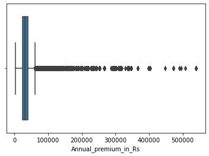

```python
sb.boxplot(x=customer_policy_data['Annual_premium_in_Rs'])
```

```python
def replace_outlier(df_in, col_name):
    q1 = df_in[col_name].quantile(0.25)
    q3 = df_in[col_name].quantile(0.75)
    iqr = q3-q1 #Interquartile range
    fence_low  = q1-1.5*iqr
    fence_high = q3+1.5*iqr
    df_out = customer_policy_data.copy()
    outliers = df_out[col_name].between(fence_low, fence_high)
    df_out.loc[outliers, col_name] = df_out.loc[~outliers,col_name].mean()
    return df_out
```

```python
replace_outlier(customer_policy_data,'Annual_premium_in_Rs')
```

|  | Customer_id | Annual_premium_in_Rs | Sales_channel_code | Vintage | Response |
| --- | --- | --- | --- | --- | --- |
| 0 | 1.0 | 77159.58072 | 26.0 | 217.0 | Yes |
| 1 | 2.0 | 77159.58072 | 26.0 | 183.0 | No |
| 2 | 3.0 | 77159.58072 | 26.0 | 27.0 | Yes |
| 3 | 4.0 | 77159.58072 | 152.0 | 203.0 | No |
| 4 | 5.0 | 77159.58072 | 152.0 | 39.0 | No |
| ... | ... | ... | ... | ... | ... |
| 381104 | 381105.0 | 77159.58072 | 26.0 | 88.0 | No |
| 381105 | 381106.0 | 77159.58072 | 152.0 | 131.0 | No |
| 381106 | 381107.0 | 77159.58072 | 160.0 | 161.0 | No |
| 381107 | 381108.0 | 77159.58072 | 124.0 | 74.0 | No |
| 381108 | 381109.0 | 77159.58072 | 26.0 | 237.0 | No |

380722 rows × 5 columns

### Dealing with duplicates

```python
customer_data.drop_duplicates()
customer_policy_data.drop_duplicates()
```

|  | Customer_id | Annual_premium_in_Rs | Sales_channel_code | Vintage | Response |
| --- | --- | --- | --- | --- | --- |
| 0 | 1.0 | 40454.0 | 26.0 | 217.0 | Yes |
| 1 | 2.0 | 33536.0 | 26.0 | 183.0 | No |
| 2 | 3.0 | 38294.0 | 26.0 | 27.0 | Yes |
| 3 | 4.0 | 28619.0 | 152.0 | 203.0 | No |
| 4 | 5.0 | 27496.0 | 152.0 | 39.0 | No |
| ... | ... | ... | ... | ... | ... |
| 381104 | 381105.0 | 30170.0 | 26.0 | 88.0 | No |
| 381105 | 381106.0 | 40016.0 | 152.0 | 131.0 | No |
| 381106 | 381107.0 | 35118.0 | 160.0 | 161.0 | No |
| 381107 | 381108.0 | 44617.0 | 124.0 | 74.0 | No |
| 381108 | 381109.0 | 41777.0 | 26.0 | 237.0 | No |

380722 rows × 5 columns

```python
Master_table=pd.merge(customer_data,customer_policy_data,on="Customer_id")
Master_table
```

|  | Customer_id | Gender | Age | Driving_licence_present | Region_code | Previously_insured | Vehicle_age | Vehicle_damage | Annual_premium_in_Rs | Sales_channel_code | Vintage | Response |
| --- | --- | --- | --- | --- | --- | --- | --- | --- | --- | --- | --- | --- |
| 0 | 1.0 | Male | 44.0 | Yes | 28.0 | 0.0 | > 2 Years | Yes | 40454.0 | 26.0 | 217.0 | Yes |
| 1 | 2.0 | Male | 76.0 | Yes | 3.0 | 0.0 | 1-2 Year | No | 33536.0 | 26.0 | 183.0 | No |
| 2 | 3.0 | Male | 47.0 | Yes | 28.0 | 0.0 | > 2 Years | Yes | 38294.0 | 26.0 | 27.0 | Yes |
| 3 | 4.0 | Male | 21.0 | Yes | 11.0 | 1.0 | < 1 Year | No | 28619.0 | 152.0 | 203.0 | No |
| 4 | 5.0 | Female | 29.0 | Yes | 41.0 | 1.0 | < 1 Year | No | 27496.0 | 152.0 | 39.0 | No |
| ... | ... | ... | ... | ... | ... | ... | ... | ... | ... | ... | ... | ... |
| 380331 | 381105.0 | Male | 74.0 | Yes | 26.0 | 1.0 | 1-2 Year | No | 30170.0 | 26.0 | 88.0 | No |
| 380332 | 381106.0 | Male | 30.0 | Yes | 37.0 | 1.0 | < 1 Year | No | 40016.0 | 152.0 | 131.0 | No |
| 380333 | 381107.0 | Male | 21.0 | Yes | 30.0 | 1.0 | < 1 Year | No | 35118.0 | 160.0 | 161.0 | No |
| 380334 | 381108.0 | Female | 68.0 | Yes | 14.0 | 0.0 | > 2 Years | Yes | 44617.0 | 124.0 | 74.0 | No |
| 380335 | 381109.0 | Male | 46.0 | Yes | 29.0 | 0.0 | 1-2 Year | No | 41777.0 | 26.0 | 237.0 | No |

380336 rows × 12 columns

```python
count=Master_table['Gender'].value_counts()
count
```

```
Male      205851
Female    174485
Name: Gender, dtype: int64
```

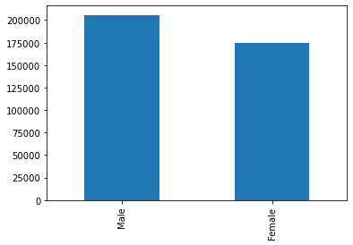

```python
count.plot.bar()
```

- Observations:
  - Male customers are taking vehicle insurence more than female

### 1. Finding the average annual premium of gender

```python
data=Master_table.groupby(['Gender'])["Annual_premium_in_Rs"].mean()
data
```

```
Gender
Female    30492.028478
Male      30623.619273
Name: Annual_premium_in_Rs, dtype: float64
```

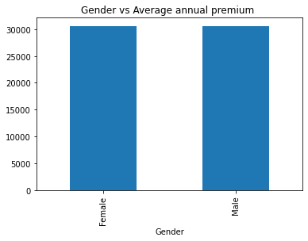

```python
data.plot.bar(title="Gender vs Average annual premium ")
plt.figure(figsize=(7,7))
plt.show()
```

- Observations
  - although female customers lower than male customers
  - Both female and male paying equal average annual premium

### 2.Finding relationship between age and annual premium with respect to vehicle_age

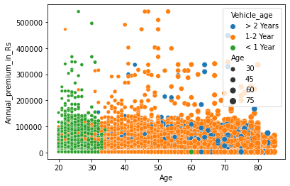

```python
sb.scatterplot(data=Master_table,x="Age",y="Annual_premium_in_Rs",hue="Vehicle_age",size="Age")
plt.show()
```

- Observations
  - The Vehicle_age <1 year are the customers in the age between 20 to 33
  - The vehicle_age 1-2 year are the customers in the age 34 to 80+ ,customers between 40 to 55 are paying high annual_premium than others

```python
data1=Master_table.groupby(['Age'])["Annual_premium_in_Rs"].sum()
data
```

```
Gender
Female    30492.028478
Male      30623.619273
Name: Annual_premium_in_Rs, dtype: float64
```

[figure not shown]

```python
data1.plot(title="Age vs Average annual premium")
plt.figure(figsize=(5,10))
plt.show()
```

- Observations
  - The older customers are having high average annual premium

### 4.Finding how many vehicles are damaged after they take the insurence

```python
data4=Master_table.groupby('Vehicle_age')["Vehicle_damage"].value_counts()
data4
```

```
Vehicle_age  Vehicle_damage
1-2 Year     Yes               128102
             No                 71979
< 1 Year     No                116112
             Yes                48192
> 2 Years    Yes                15936
             No                    15
Name: Vehicle_damage, dtype: int64
```

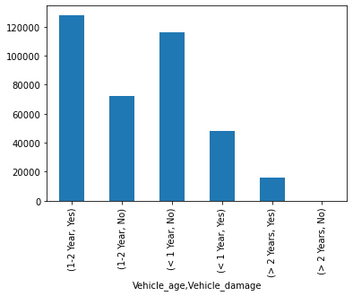

```python
data4.plot.bar()
```

- Observations
  - The vehicle-age between 1-2 years of the vehicles are highly damaging